# Tema 4 - Variables Aleatorias continuas

## Ejemplo: Distribución uniforme en \([0,1]\).

**Ejemplo: número aleatorio entre \(0\) y \(1\)**

Supongamos que elegimos un número al azar en el intervalo \([0,1]\).

Consideremos la v.a. continua \(X=\) número elegido.

Su función de distribución es

\[ F_{X}(x)= \left\{ \begin{array}{ll} 0, & \mbox{si } x\leq 0,\\ x, & \mbox{si } 0<x<1,\\ 1, & \mbox{si } x\geq 1. \end{array} \right. \]

consideremos

- C.F. *longitud favorable* que es \(x-0\),
- C.P. *longitud posible* que es \(1-0\),

luego

\[P(X\leq x)=\frac{C.F.}{C.P.}=\frac{x-0}{1-0}=x.\]

## Gráfica de la función de distribución uniforme

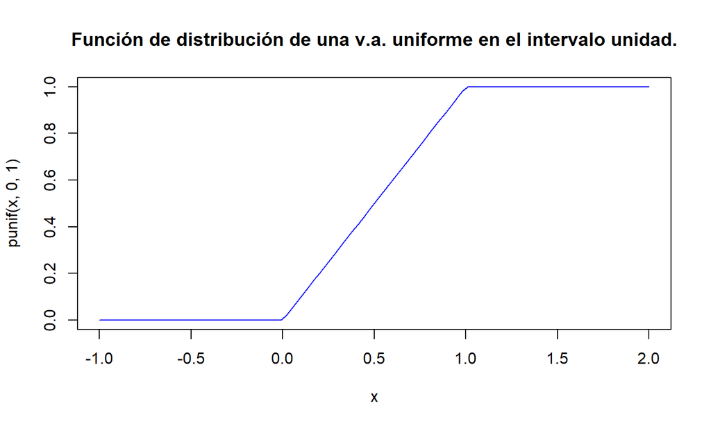

## Función de densidad

Función de densidad

Una función \(f:\mathbb{R}\to\mathbb{R}\) es una función de densidad sobre \(\mathbb{R}\) si cumple que

- \(f_{X}(x)\geq 0\) para todo \(x \in\mathbb{R}.\)
- \(f\) es continua salvo a lo más en una cantidad finita de puntos sobre cada intervalo acotado de \(\mathbb{R}\).
- \(\displaystyle\int\limits_{-\infty}^{+\infty} f_{X}(x) dx=1.\)

## Función de distribución de una variable aleatoria.

**Función de distribución de una variable aleatoria**

Sea \(X\) una v.a. con función de distribución \(F_X\). Sea \(f:\mathbb{R}\to\mathbb{R}\) una función de densidad tal que

\[F_X(x)=P(X\leq x)=\displaystyle\int_{-\infty}^{x} f_X(t)\ dt.\mbox{ para todo } x\in\mathbb{R},\]

Entonces \(X\) es una variable aleatoria continua y \(f_X\) es la densidad de la v.a. \(X\).

## Dominio de una variable aleatoria continua

El conjunto \(D_X=\{x\in\mathbb{R}| f_x(x)>0\}\) recibe el nombre de soporte o dominio de la variable aleatoria continua y se interpreta como su conjunto de resultados posibles.

**Ejemplo:**

En nuestro ejemplo, la función \(f\) es una densidad

\[ f_{X}(x)=\left\{ \begin{array}{ll} 0, & \mbox{si } x\leq 0,\\ 1, & \mbox{si } 0 < x < 1,\\ 0, & \mbox{si } 1\leq x. \end{array}\right. \]

que es la densidad de \(X\), en efecto:

## Ejemplo

\[ f_{X}(x)=\left\{ \begin{array}{ll} 0, & \mbox{si } x\leq 0,\\ 1, & \mbox{si } 0 < x < 1,\\ 0, & \mbox{si } 1\leq x. \end{array}\right. \]

- Si \(x \leq 0\) entonces \(\displaystyle\int_{-\infty}^x f_X(t) dt = 0.\)
- Si \(0\leq x\leq 1\) entonces \(\displaystyle\int_{-\infty}^x f_X(t) dt = \int_0^x 1 dt = x.\)
- Si \(x\geq 1\) entonces \(\displaystyle\int_{-\infty}^x f_X(t) dt = \int_0^1 1 dt = 1.\)

Por lo tanto, \(F_X(x)=\displaystyle\int_{-\infty}^x f_X(t) dt\) para todo \(x\in\mathbb{R}.\)

## Ejemplo

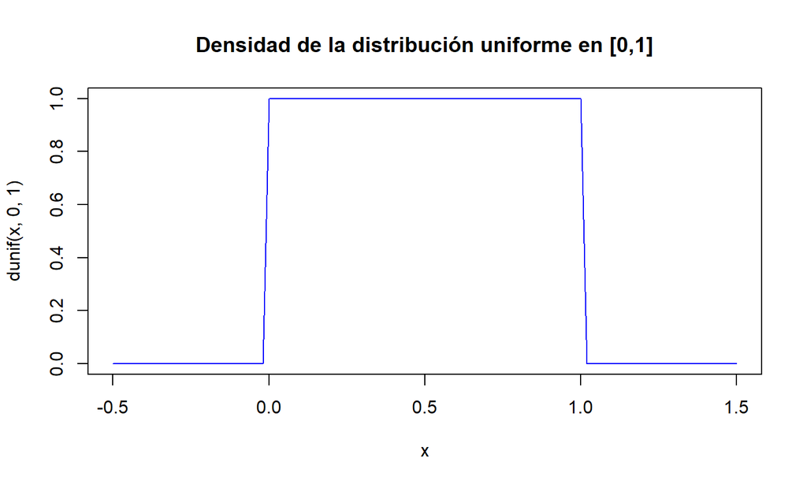

## Propiedades de la función de densidad

La función de densidad nos permite calcular diversas probabilidades.

Propiedades de la función de densidad

- Sea \(X\) una v.a. continua con función de distribución \(F_X\) y de densidad \(f_X\), entonces \[\begin{eqnarray*} P(a< X< b) &=& P(a<X\leq b)= P(a\leq X< b)=\\ & & P(a\leq X\leq b)= \displaystyle\int_{a}^b f_X(x) dx. \end{eqnarray*} \]
- Si \(A\) es un subconjunto adecuado de \(\mathbb{R}\) entonces \[P(X\in A)=\displaystyle\int_{A} f(x) dx=\displaystyle\int_{A\cap D_X} f(x) dx. \]

## Utilidad de la función de densidad

Propiedades de la función de densidad

Sea \(X\) una v.a. continua con función de distribución \(F_X\) y de densidad \(f_X\), entonces:

- Si \(f_x\) es continua en un punto \(x\), \(F_X\) es derivable en ese punto y \(F_X'(x)=f_X(x).\)
- \(P(X=x)=0\) para todo \(x\in\mathbb{R}.\)

## Esperanza y varianza

## Esperanza y varianza

Esperanza v.a. continuas

- Su esperanza es: \[E(X)=\displaystyle\int\limits_{-\infty}^{+\infty} x\cdot f_{X}(x)dx.\]
- Si \(g(x)\) es una función de la variable \(X\) entonces: \[E(g(X))=\displaystyle\int\limits_{-\infty}^{+\infty} g(x)\cdot f_{X}(x)dx.\]

## Esperanza y varianza

Varianza v.a. continuas

- Su varianza es: \[ Var(X)=\sigma_{X}^2=E((X-\mu_{X})^2)= \displaystyle\int\limits_{-\infty}^{+\infty} (x-\mu_{X})^2 \cdot f_{X}(x)dx. \]
- Su desviación típica es: \[\sigma_{X}=+\sqrt{\sigma_{X}^2}.\]

## Propiedades

Propiedades

- \(\sigma_{X}^2\geq 0\).
- \(Var(cte)=E(cte^2)-(E(cte))^2= cte^2 - cte^2=0\).
- \(\displaystyle Var(x)=E(X^2)-\mu_{X}^2=\int_{-\infty}^{+\infty}x^2\cdot f_{X}(x)dx - \mu_{X}^2.\)
- El mínimo de \(E((X-C)^2)\) se alcanza cuando \(C=E(X)\) y es \(Var(X)\).

## Transformaciones lineales de v.a. continuas

Proposición

Sea \(X\) una v.a. continua con \(E(X)=\mu_{X}\) y \(Var(X)=\sigma_{X}^2\) sea \(Y=a+b X\), donde \(a,b\in\mathbb{R}\), es una nueva v.a. continua obtenida mediante una transformación lineal de \(X\). Se verifican las mismas propiedades que en el caso discreto:

- \(E(Y)=E(a+b\cdot X)=a+b\cdot E(X)\).
- \(Var(Y)=Var(a+b\cdot X)=b^2 \cdot Var(X)\).
- \(\sigma_{Y}=|b|\cdot \sigma_{X}\).
- \(Z=\frac{X-\mu_{X}}{\sigma_{X}}\) es una transformación lineal de \(X\) de forma que \[E(Z)=0 \mbox{ y } Var(Z)=1\]

## Distribuciones continuas notables

## V.a con distribución uniforme, \(U(a,b)\)

| Distribución uniforme | \(U(a,b)\) |
| --- | --- |
| Dominio | \(D_X=(a,b)\) |
| \(f_{X}(x)\) | \(\left\{\begin{array}{ll}\frac1{b-a}, & \mbox{si } a<x<b,\\ 0, & \mbox{en cualquier otro caso.}\end{array} \right.\) |
| \(F_X(x)=P(X\leq X)=\) | \(\left\{\begin{array}{ll} 0, & \mbox{ si } x\leq a\\\frac{x-a}{b-a}, & \mbox{ si } a\leq x\leq b,\\1, & \mbox{ si } b\leq x.\end{array}\right.\) |
| \(E(X)=\) | \(\frac{a+b}2\) |
| \(Var(X)=\) | \(\frac{(b-a)^2}{12}\) |

## Gráficas \(U(0,1)\)

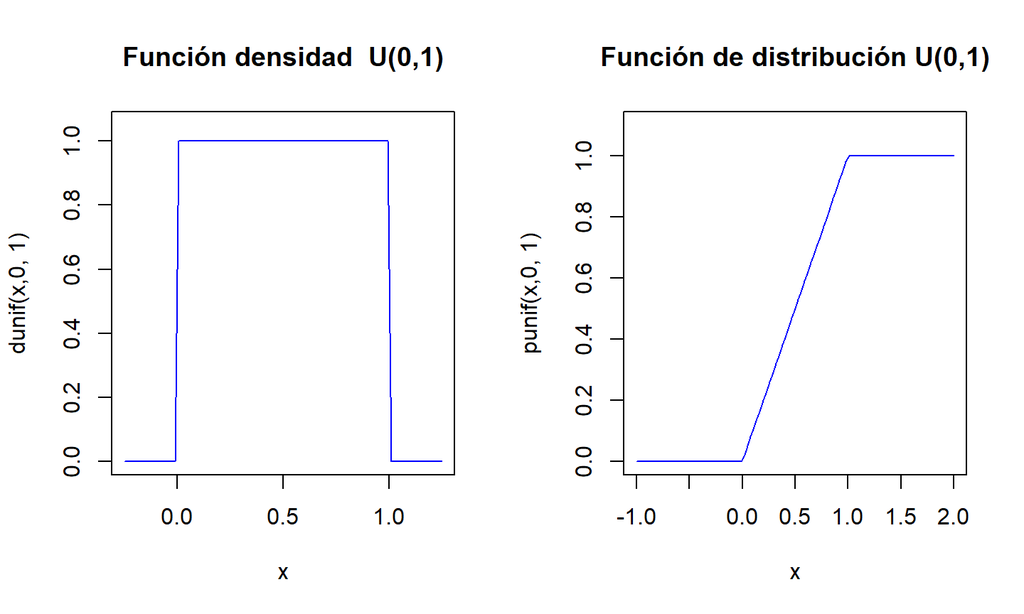

## V.a. con distribución exponencial, \(Exp(\lambda)\)

| \(X\) | \(Exp(\lambda)\) |
| --- | --- |
| \(D_X=\) | \((0,+\infty)\) |
| \(f_{X}(x)=\) | \(\left\{\begin{array}{ll} \lambda e^{-\lambda x} & \mbox{ si } x>0\\ 0 & \mbox{ si } x\leq 0 \end{array}\right.\) |
| \(F_X(x)=P(X\leq X)=\) | \(\left\{\begin{array}{ll} 0 &\mbox{si } x\leq 0\\ 1-e^{-\lambda x}& \mbox{si } x>0\end{array}\right.\) |
| \(E(X)=\frac{1}{\lambda}\) | \(Var(X)=\frac{1}{\lambda^2}\) |

## Gráficas densidad y distribución \(Exp(\lambda=10)\)

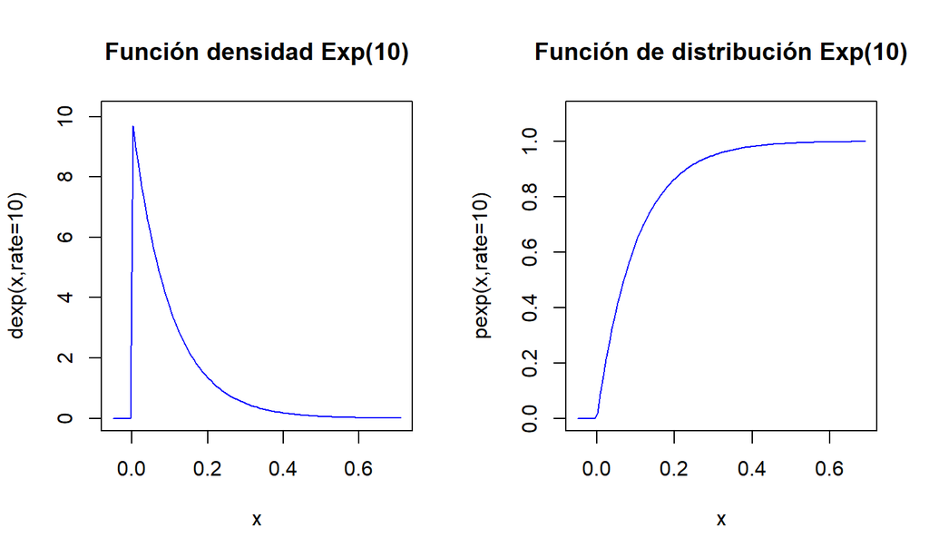

## V.a. con distribución normal, \(N(\mu,\sigma)\)

| \(X\) | \(N(\mu,\sigma)\) |
| --- | --- |
| \(D_X=\) | \(\mathbb{R}=(-\infty,+\infty)\) |
| \(f_{X}(x)\) | \(=\frac{1}{\sqrt{2\pi\cdot\sigma^2}}\cdot e^{\frac{-(x-\mu)^2}{2\cdot \sigma^2}}\mbox{ para todo }x\in \mathbb{R}.\) |
| \(F_X(x)=P(X\leq X)=\) | Usar algún software estadístico |
| \(E(X)=\mu.\) | \(Var(X)=\sigma^2.\) |

## Propiedades de la distribución normal.

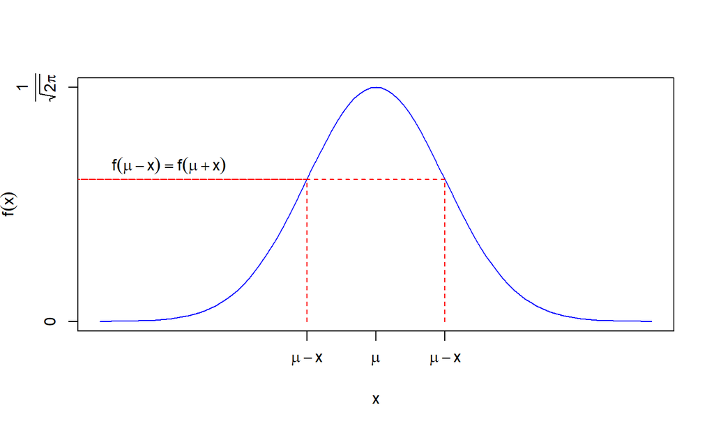

## Propiedades de la distribución normal.

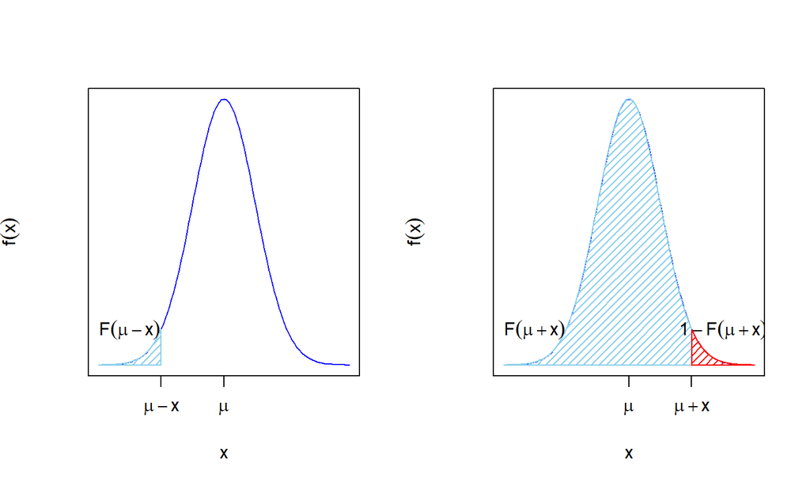

## Transformaciones lineales de variables aleatorias normales

Propiedad: transformación lineal la distribución normal

Sea \(X\) una variable \(N(\mu,\sigma)\) entonces la variable \(Y=a X+b\) con \(a\not=0,b\in\mathbb{R}\) tiene distribución \(N(a\mu+b, |a| \sigma)\)

En particular si \(X\) sigue una \(N(\mu,\sigma)\), tomando \(a=\frac1{\sigma}\) y \(b= \frac{-\mu}{\sigma}\) obtenemos la tipificación o estandarización de la v.a.

\[Z={{X-\mu}\over {\sigma}}\] se distribuye \(N(0,1)\), es decir \(E(X)=0\) y \(Var(X)=1\).